# Machine Learning Programming

# Assignment 5: Gaussian Mixture Model Applications (GMMApps)

This series of practicals focus on the development of machine learning algorithms introduced in the Applied Machine Learning course. In this practical, you will apply the previously programmed Gaussian Mixture Models (GMM) algorithm to clustering, regression and resampling problems.

**Deadline: December 12th, 2023 @ 8pm**

Assignments must be turned in by the deadline. **1/6 point will be removed for each day late (a day late starts one hour after the deadline).**

**Procedure:** From the course Moodle webpage, you must download and extract the `.zip` file named `TP5-GMMApps-Assignment.zip`. The folder contains the following elements:

- tp5_gmmapps_part1.m
- tp5_gmmapps_part2.m
- tp5_gmmapps_part3.m
- **functions**
  - **part1**
  - **part2**
  - **part3**
- **plot_functions**
- **data**
- **utils**

Only the elements in blue need to be filled out. The rest are helper functions or data to be imported. This assignment will be less guided than the previous ones. There are no evaluation functions provided.

You must submit an archive as a `.zip` file with the following naming convention `TP5-GMMApps-SCIPER.zip`, where `SCIPER` need to be replaced by your own **sciper number**. You must submit **only** the files/folders in blue. **DO NOT INCLUDE** the folders **plot_functions**, **data**, and **utils**.

We take plagiarism very seriously. Submitting works that are not yours will result in a report submitted to the competent EPFL authorities.

# Part 1: Classification with GMM+Bayes

In the previous assignment, we have implemented the GMM model to fit a dataset in a complete unsupervised manner. To recall, given a dataset $\mathbf{X} = \{\mathbf{x}^1,\dots,\mathbf{x}^M\}$ where $\mathbf{x}^i \in \mathbb{R}^N$, the probability density function (pdf) of a $K$-component GMM is of the form,

\begin{equation} p(\mathbf{x}|\Theta) = \sum\limits_{k=1}^{K} \alpha_k p(\mathbf{x}| \mathbf{\mu}^k, \mathbf{\Sigma}^k) \end{equation}

where $p(\mathbf{x}| \mathbf{\mu}^k, \mathbf{\Sigma}^k)$ is the multivariate Gaussian pdf with mean $\mathbf{\mu}^k$ and covariance $\mathbf{\Sigma}^k$

\begin{equation} \begin{aligned} p(\mathbf{x}|\mu^k,\Sigma^k) & = \frac{1}{(2\pi)^{N/2}|\Sigma^k|^{1/2}} \exp \left\lbrace -\frac{1}{2}(\mathbf{x} - \mu^k)^{T} ( \Sigma^k )^{-1} (\mathbf{x} - \mu^k) \right\rbrace\\ \end{aligned}. \end{equation}

$\Theta= \{\theta^1, \dots, \theta^k\}$ is the complete set of parameters $\theta_k= \{\alpha_k, \mu^k, \Sigma^k\}$, where $\alpha_k$ are the priors (or mixing weights) of each Gaussian component, satisfying the constraint $\sum_{k=1}^{K}\alpha_k = 1$. These parameters are typically learned through the iterative Expectation-Maximization algorithm, which was implemented in the previous assignment.

In this part, we want to decide to which class each datapoint belongs to with models of each class learnt *a priori*, in other words classification. To perform classification, we need to create a **training** dataset (i.e. a labeled dataset to build our model) and a **testing** dataset to evaluate the performance of the algorithm. To perform classification with GMMs, the first step is to learn a GMM for each class from the **training** set. Given a model for each class, we can use the Gaussian Likelihood Discriminant Rule to classify the **testing** datapoints.

## Learning a GMM for each class

You will have access to a library of functions in `utils/datasets` folder that generate datasets of 2 to 4 classes as shown below. Those functions return sets of $(x,y)$ points where the class labels $y$ are stored in the last column of the returned variable. Each functions can take optional parameters but the easiest usage is to use the default values by passing no arguments. An example of the functions calling is written in the file `datasetsdemo.m` and produces the following figure.

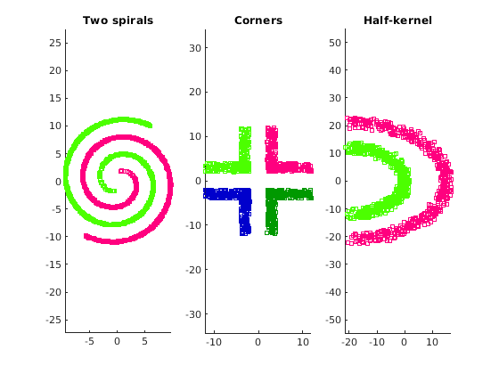

```matlab
datasetsdemo()
```

Using the previously developed functions for learning the parameters of a Gaussian Mixture model via EM algorithm, one can learn **one GMM for each of the classes** on the **training** dataset.

## Gaussian Maximum Likelihood Discriminant Rule

A maximum likelihood classifier chooses the class label that is the most likely. For a binary classification problem, a new datapoint $\mathbf{x'}$ belongs to class $1$ if the corresponding likelihood is superior to the likelihood of class 2,

\begin{equation} p(y=1|\mathbf{x'}) > p(y=2|\mathbf{x'}). \end{equation}

By Bayes, we have \begin{equation} p(y=i|\mathbf{x'}) = \dfrac{p(\mathbf{x'}|y = i) p(y = i)}{p(\mathbf{x'})}, \text{with class $i = 1, 2$}. \end{equation}

Replacing this term in the Maximum Likelihood (ML) Discriminant Rule for $\mathbf{x'}$ in class $1$, we obtain

\begin{equation} p(\mathbf{x'}|y = 1) p(y = 1) > p(\mathbf{x'}|y = 2) p(y = 2). \end{equation}

In general, one can assume equal class distribution, i.e. $p(y=1) = p(y=2)$. By replacing in the previous equation, the discriminant rule becomes

\begin{equation} p(\mathbf{x'}|y = 1) > p(\mathbf{x'}|y = 2). \end{equation}

For a GMM composed of $K^i$ multivariate Gaussian functions, the conditional densities to belong to class $i$ is similar to the PDF equation,

\begin{equation} p(\mathbf{x'}|y = i) = \sum\limits_{k=1}^{K^i} \alpha_k p(\mathbf{x'}| \mathbf{\mu}^k, \mathbf{\Sigma}^k), \end{equation}

with $p(\mathbf{x'}| \mathbf{\mu}^k, \mathbf{\Sigma}^k)$ defined according to PDF equation of the GMM.

In the case of a multi-class problem with $i = 1... I$ classes, the ML Discriminant Rule is the minimum of the log-likelihood (i.e., equivalent to maximizing the likelihood). **Assuming equal class distribution**, the ML Discriminant Rule is:

\begin{equation} c_i(\mathbf{x'}) = \mathop{\mathrm{argmin}} \left\lbrace -\log(p(\mathbf{x'}|y = i)) \right\rbrace. \end{equation}

In the case that one **does not make the assumption of equal class distribution**, the ML Discriminant Rule is:

\begin{equation} c_i(\mathbf{x'}) = \mathop{\mathrm{argmin}} \left\lbrace -\log(p(\mathbf{x'}|y = i)p(y=i)) \right\rbrace. \end{equation}

## TASK 1: Implement `initialize_parameters.m` function (2pts)

The function has the following signature:

```matlab
function [data, Xtrain, Ytrain, Xtest, Ytest, params] = initialize_parameters(dataset_type)
```

Given a string `dataset_type` which indicates the dataset to select (i.e the function to call from the `utils/datasets` folder among `halfkernel`, `corners`, and `twospirals`), this function returns the generated data and a splitted **training** and **testing** datasets. It also initializes the structure of hyperparameters `params` needed for the GMM algorithm. You have to provide a set of parameters that will allow to learn a GMM model on **each of the three dataset** ensuring no **overfitting** or **underfitting**. The parameters to fill are:

- **training/testing ratio:** the ratio between `train` and `test` dataset. It is a single double value. Be careful about its meaning. **0.5** is **not** a valid option.
- **number of Gaussians k:** as stated, represents the number of Gaussians, as an integer value, to use in the GMM.
- **type of covariance matrix:** a string (`iso`, `diag` or `full`) representing the type of covariance matrix of the Gaussians.

This choice of parameters, especially the number of Gaussians and the type of covariance, has to take into account the **complexity** of the chosen model. These parameters vary depending on the selected dataset.

**Note:** We do not ask you to compute evaluatiom metrics that would automatically provide the combination of hyperparameters the most adapted. This will be done in **Part 3**. Here we ask you to give an **educated guess**. There are multiple answers possible.

**Useful functions**: All the dataset generation functions from `utils/datasets` folder, `split_data` function from the `utils` folder.

## Task 2: Implement `gmm_models.m` function (2pts)

The function has the following signature:

```matlab
function [models] = gmm_models(Xtrain, Ytrain, params)
```

Using the previously developed functions for learning the parameters of a Gaussian Mixture model via **EM algorithm**, learn a GMM **for each of the classes** on the **training** dataset. Note that you should consider one GMM per class. Here we consider that each GMM uses the same hyperparameters (number of Gaussians and type of covariance matrix).

The function should return the learned parameters $(\alpha, \mu, \Sigma)$ for all the GMMs, stored in the output structure array `models`.

**Useful function**: `gmmEM`

Running the script `tp5_gmmapps_part1.m` produces an image of the contour of the learned GMM for each of the class labels. For example, on the `halfkernel` dataset:

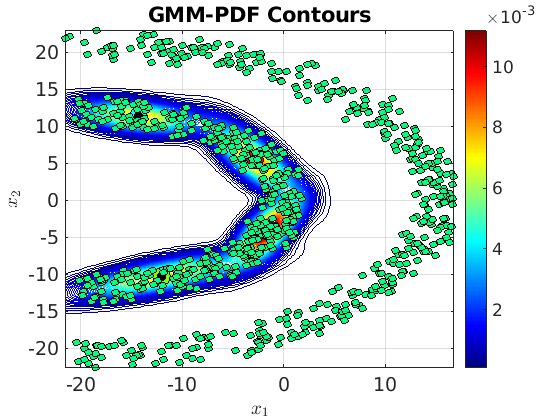

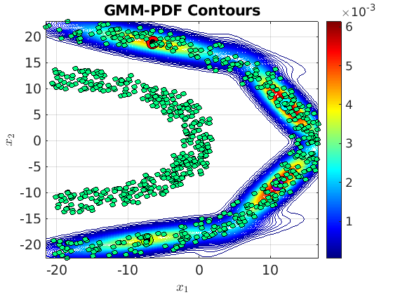

```matlab
plot_fitted_dataset(Xtrain, Ytrain, models)
```

**Note:** The image you will obtain obviously depends on the hyperparameters you have selected to train the GMM. Therefore, it might differ from the one above.

## TASK 3: Implement `gmm_classifier.m` function (3pts)

The function has the following signature:

```matlab
function [Yest] = gmm_classifier(Xtest, models, labels)
```

Implement the ML Discriminant Rule to estimate labels `y_est` for each datapoints in `Xtest` **assuming equal class distribution**. For this assignment you don't have to consider the case of unbalanced dataset but bear in minds that this requires extra care in case you encounter it in the future. The `labels` argument is a vector containing the mapping between the index of the GMM and the associated label. Remember that indexing starts at 1 in Matlab but index 1 could correspond to label 0, for example.

We can oberve the results by plotting the boundaries of the classification on the **testing** dataset.

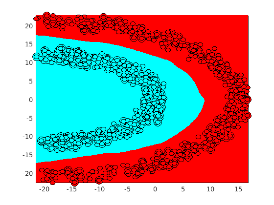

```matlab
plot_boundaries(Xtrain, Ytrain, Xtest, Ytest, Yest,  models);
```

# Part 2: Resampling from learned GMMs

One of the biggest problem of machine learning is the cost of gathering data coupled to the fact that complex ML algorihtms requires a lot of them. The beauty of GMMs is that it is able to learn the underlying structure of a given set of points, which is often refered as **density estimation**. That is to say, the result of a GMM fit to some data is technically not a clustering model, but a generative probabilistic model describing the distribution of the data. Therefore, one can draw samples from such a probabilistic model, i.e. generate new data points that are not part of the dataset but share its underlying structure. With this, one can create fake data to extand its dataset, or also solve the **unbalanced dataset** problem by generating more samples of the classes that are missing some.

Drawing samples from a GMM is using the probabilistic model as a random generator. This is a two-steps process. First, one must select which Gaussian $k$ to draw a sample from based on the **prior probabilities** $\alpha$ of the GMM. A Gaussian with a higher prior probability is most likely to be selected. Once a Gaussian is selected, a datapoint is drawn from the **multivariate distribution** given by the paramater $\mu$ and $\Sigma$ of the selected Gaussian.

## Task 4: Implement `sample_from_gmm.m` function (2pts)

The function has the following signature:

```matlab
function [XNew] = sample_from_gmm(gmm, nbSamples)
```

It takes as input the `gmm` structure that contains the parameters of the learned GMM, i.e $\alpha$, $\mu$ and $\Sigma$. The second argument `nbSamples` corresponds to the number of new samples to generate from the learned GMM.

**Useful functions**: `randsrc()`, `mvnrnd()`

By running the script `tp5_gmmapps_part2.m` you can test this approach on the datasets from part 1. For example, on the halfkernel dataset, if we use `k=4`, this produces:

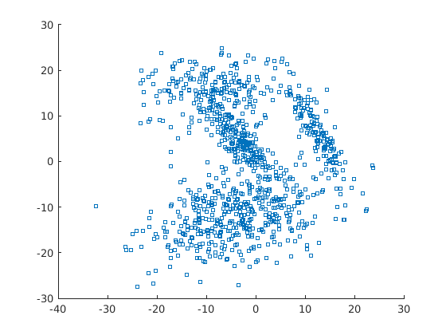

```matlab
scatter(XNew(1,:), XNew(2,:), dotsize);
```

As we can see, because our dataset is underfitted this results in poorly representative samples. Increasing to `k=25` yields better results:

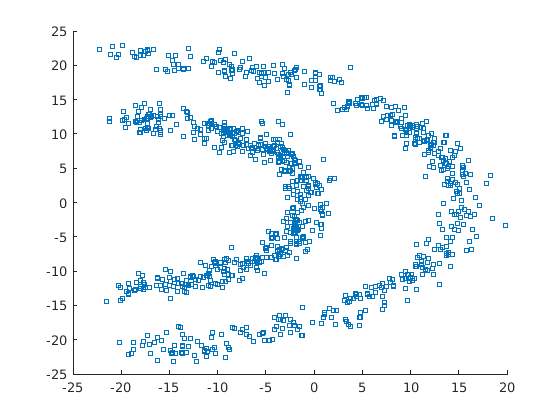

```matlab
scatter(XNew(1,:), XNew(2,:), dotsize);
```

## Sampling high dimensional data

We can also apply the same method to a large dimensional dataset such as the [mnist handwriting dataset](http://yann.lecun.com/exdb/mnist/):

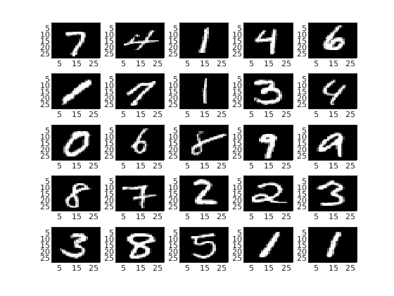

```matlab
plot_digits(Xtrain)
```

Because the number of dimensions is too high, one must first apply the PCA algorithm on the data and learn the GMM on the **latent space** (result of the PCA). Applying the previous function, with `k=200` gives:

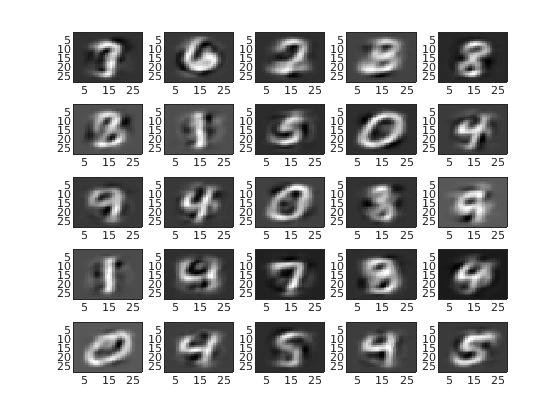

```matlab
plot_digits(XHat)
```

## Sampling with supervised learning

Instead of using an unsupervised approach, we can also rely on the fact that we know the labels associated to the existing samples and draw new samples for a specific class. To do that we will use the clustering method from part 1 and apply it on the mnist dataset. Instead of sampling from a single GMM learned over the whole dataset, we will now sample from the model of the 10 GMM (one GMM learned per class).

## Task 5: Implement `sample_from_gmmModels.m` function (2pts)

The function has the following signature:

```matlab
function [XNew] = sample_from_gmmModels(models, nbSamplesPerClass, desiredClass)
```

The `desiredClass` argument is optional and, if provided allows to generate only samples of a desired class. If not provided, it should then generate samples for all the classes. Using this supervised approach yields the following results:

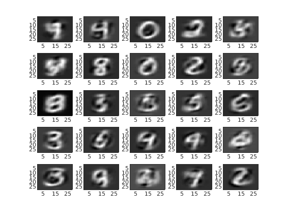

```matlab
plot_digits(XHat)
```

When asking specefically for the class 4 we obtain:

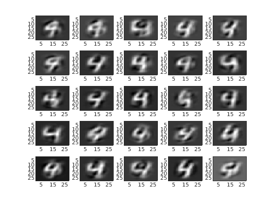

```matlab
plot_digits(XHat)
```

# Part 3: Gaussian Mixture Regression (GMR)

Regression problems are a category of **supervised learning** algorithms that seeks to approximate the true mapping function $\mathbf{y}=f(\mathbf{x})$ from inputs $\mathbf{x}$ to outputs $\mathbf{y}$ from a set of training data. As opposed to classification, in **regression**, the output variables are continuous $y\in\mathcal{R}$. Such regression problems are found in a wide spectrum of research from financial to robotic applications.

Any regression problem is posed as follows, given a training data set of inputs $\mathbf{X} = \{ \mathbf{x}^1,\dots,\mathbf{x}^M \}$ of $M$ samples, where $\mathbf{x}^{i}\in \mathbb{R}^N$ are $N$-dimensional inputs and a set of corresponding outputs $\mathbf{y} = \{ \mathbf{y}^1,\dots,\mathbf{y}^M \}$, where $\mathbf{y}^i \in \mathbb{R}^P$ are continuous $P$-dimensional outputs, we seek to approximate a continuous mapping function $\hat{f}: \mathbb{R}^N \rightarrow \mathbb{R}^P$, $\hat{\mathbf{y}}=\hat{f}(\mathbf{x})$, that best recovers the true **regressive function** $\mathbf{y}=f(\mathbf{x})$.

Many linear/non-linear methods exist to obtain this regressive function $f(\mathbf{x})$. In this assignment we will implement a version using our previously implemented GMMs, **Gaussian Mixture Regression**. For further reading on these regression methods, refer to the [Regression Slides](http://lasa.epfl.ch/teaching/lectures/ML_Msc/Slides/Regression.pdf) or the **lecture Notes** from the [Applied Machine Learning course](http://lasa.epfl.ch/teaching/lectures/ML_Msc/index.php).

**Gaussian Mixture Regression** is a **parametric model-based** method, capable of learning a regressive function of **non-linear** datasets. It stems from estimating a joint density of the inputs and outputs through a $K$-component Gaussian mixture model as follows:

\begin{equation} p(\mathbf{x},\mathbf{y} |\Theta ) = \sum\limits_{k=1}^{K}\alpha_k p(\mathbf{x},\mathbf{y}|\mathbf{\mu}^k, \mathbf{\Sigma}^k), \end{equation}

where $\alpha_k$ are the priors of each Gaussian component parametrized by $\{\mathbf{\mu}^k. \mathbf{\Sigma}^k\}$ where

\begin{equation} \sum\limits_{k=1}^{K}\alpha_k = 1, \qquad \mu^k = \begin{bmatrix} \mathbf{\mu}^k_{\mathbf{x}} \\ \mathbf{\mu}^k_{\mathbf{y}} \end{bmatrix}, \qquad \mathbf{\Sigma}^k = \begin{bmatrix} \mathbf{\Sigma}^k_{\mathbf{xx}} & \mathbf{\Sigma}^k_{\mathbf{xy}}\\ \mathbf{\Sigma}^k_{\mathbf{yx}} & \mathbf{\Sigma}^k_{\mathbf{yy}} \end{bmatrix}. \end{equation}

Given this joint density, one can compute the conditional density $p(\mathbf{y}|\mathbf{x})$ which will provide our regressive function $y = f(x)$,

\begin{equation} p(\mathbf{y}|\mathbf{x}) = \sum\limits_{k=1}^{K}\beta_k p(\mathbf{y}|\mathbf{x};\mathbf{\mu}^k, \mathbf{\Sigma}^k) \end{equation}

where

\begin{equation} \label{eq:beta} \beta_k = \frac{\alpha_k p(\mathbf{x}|\mathbf{\mu_x}^k, \mathbf{\Sigma_{xx}}^k)}{\sum\limits_{k=1}^{K} \alpha_k p(\mathbf{x}|\mathbf{\mu_x}^k, \mathbf{\Sigma_{xx}}^k)}. \end{equation}

The $\beta_k$ parameters are known as the mixing weights (i.e. relative importance) of each $K$-th regressive model $p(\mathbf{y}|\mathbf{x};\mathbf{\mu}^k, \mathbf{\Sigma}^k)$. The **regressive function** is then obtained by computing the expectation over the conditional density $\mathbb{E}\{p(\mathbf{y}|\mathbf{x})\}$ as follows:

\begin{equation} \label{eq:GMR} \begin{aligned} y = & f(\mathbf{x}) = \mathbb{E}\{p(\mathbf{y}|\mathbf{x})\} = \sum\limits_{k=1}^{K}\beta_k(\mathbf{x})\tilde{\mu}^k(\mathbf{x}) \end{aligned} \end{equation}

where

\begin{equation} \tilde{\mu}^k(\mathbf{x}) = \mu_{\mathbf{y}} ^k + \mathbf{\Sigma}_{\mathbf{yx}}^k(\mathbf{\Sigma}_{\mathbf{xx}}^k)^{-1}(\mathbf{x}-\mu_{\mathbf{x}}^k) \end{equation}

are the local regressive functions, which represent a linear function whose slope is determined by $\mathbf{\Sigma}_{\mathbf{x}}^k$ (the variance of $\mathbf{x}$) and $\mathbf{\Sigma}_{\mathbf{xy}}^k$ (the covariance of $\mathbf{y}$ and $\mathbf{x}$). Our regressive function $y=f(\mathbf{x})$ is thus a linear combination of $K$ regressive models. The advantage of GMR over other non-linear regressive methods is that we can also compute the uncertainty of the prediction (i.e. the regressed output $\hat{y}$) by computing the variance of the conditional function $Var\{p(\mathbf{y}|\mathbf{x})\}$ as follows:

\begin{equation} \label{eq:GMR-var} Var\{p(\mathbf{y}|\mathbf{x})\} = \sum\limits_{i=1}^{K} \beta_k(\mathbf{x}) \left( \tilde{\mu}^k(\mathbf{x})^2 + (\tilde{\mathbf{\Sigma}}^k) \right) - \left( \sum\limits_{i=1}^{K} \beta_k(\mathbf{x})\tilde{\mu}^k(\mathbf{x}) \right)^2 \end{equation}

where $\tilde{\mathbf{\Sigma}}^k$ represents the variance of the conditional density for each regressive function and is computed as follows:

\begin{equation} \tilde{\mathbf{\Sigma}}^k = \mathbf{\Sigma}_{\mathbf{yy}}^k - \mathbf{\Sigma}_{\mathbf{yx}}^k(\mathbf{\Sigma}_{\mathbf{xx}}^k)^{-1}\mathbf{\Sigma}_{\mathbf{xy}}^k \end{equation}

Note that $Var\{p(\mathbf{y}|\mathbf{x})\}$ represents the uncertainty of the **prediction** NOT of the model. To represent the uncertainty of the model one should compute the likelihood of the joint density; i.e. $\mathcal{L}(\Theta|\mathbf{X},\mathbf{y}) = \prod\limits_{i=1}^{M}\sum\limits_{k=1}^{K}\alpha_k p(\mathbf{x},\mathbf{y}|\mathbf{\mu}^k, \mathbf{\Sigma}^k)$. Another advantage of GMR over most regression methods is that it can be used with multi-dimensional inputs $\mathbf{x} \in \mathbb{R}^N$ as well as multi-dimensional outputs $\mathbf{y} \in \mathbb{R}^P$, with the same formulation presented here. For a thorough description of the derivation of this method we recommend reading Hsi Guang Sung's PhD Thesis and Cohn et al's seminal work on learning with statistical models

**Step 1**: Estimate a Joint Density $p(\mathbf{x},\mathbf{y}|\Theta)$ of your Dataset {$\mathbf{X}$,$\mathbf{y}$} with a GMM}} The first step in implementing GMR is to learn the joint density of the inputs $\mathbf{X} \in \mathbb{R}^{M\times N}$ and outputs $\mathbf{y} \in \mathbb{R}^{M\times P}$, where $N$ and $P$ correspond to the dimensionality of the input and output spaces, respectively. By loading one of the three different 1-D datasets provided in the script `tp5_gmmapps_part3.m` and selecting the values of $K$ and `cov_type` you will fit a GMM to your regression dataset.

**Step 2**: Compute the Expectation and Variance of the Conditional $p(\mathbf{y}|\mathbf{x})$ Once the GMM parameters are estimated for the joint dataset {$\mathbf{X}$,$\mathbf{y}$} we can estimate the regressive function by implementing the previously defined equations.

## Task 6: Implement `gmr.m` function (4pts)

The function has the following signature:

```matlab
function [y_est, var_est] = gmr(Priors, Mu, Sigma, X, in, out)
```

The inputs for the function are the GMM parameters $\Theta = \{\mathbf{\alpha},\mathbf{\mu},\mathbf{\Sigma}\}$ estimated in the previous step, as well as $\mathbf{X}$ the input data to regress on and the variables `in` and `out` which correspond to the indices of the input ($N$) and output ($P$) dimensions of the $D$-dimensional $D = (N+P)$ joint dataset used to train the GMM parameters. The outputs are `y_est` and `var_est`, results of the previously defined equations. `in` and `out` arguments are index vectors that can be directly used to index `Mu` and `Sigma` at the correct dimensions (cf indexing from the exercise session).

The script `tp5_gmmapps_part3.m` will load a 1D Regression Datasets. There are three possible dataset, available by changing the value in `dataset_type` to either `1d-sine`, `1d-linear`, or `1d-sinc`:

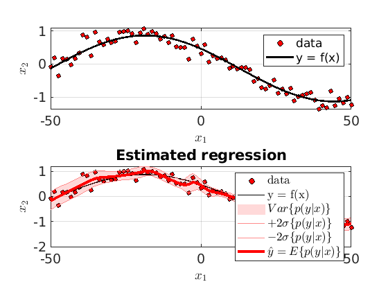

```matlab
plot_regression(X, y, y_true, y_est, var_est, '1d-sine Dataset');
```

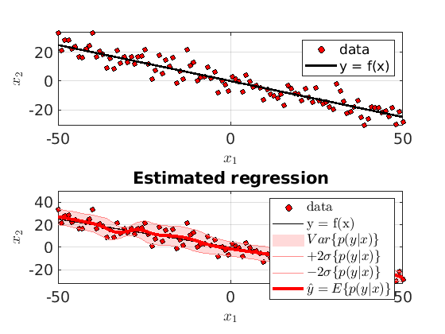

```matlab
plot_regression(X, y, y_true, y_est, var_est, '1d-linear Dataset');
```

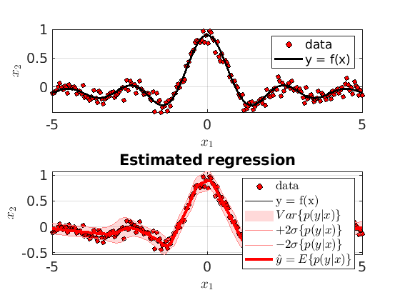

```matlab
plot_regression(X, y, y_true, y_est, var_est, '1d-sinc Dataset');
```

Additionally, the same function can be applied on **2D Datasets**. The list of available 2D dataset is `2d-cossine` and `2d-gmm`. Change the value in `dataset_type` to load a different dataset:

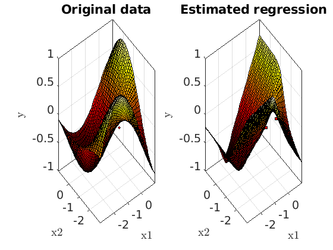

```matlab
plot_2Dregression(X, y, ftruth, f)
```

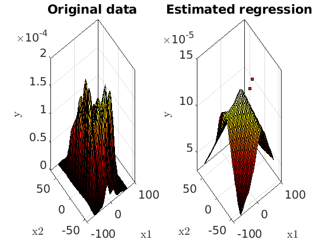

```matlab
plot_2Dregression(X, y, ftruth, f)
```

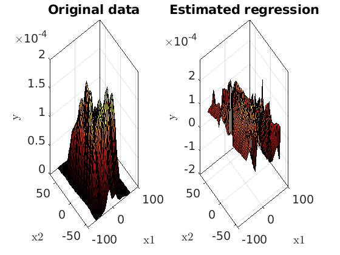

```matlab
plot_2Dregression(X, y, ftruth, f)
```

Note that for such type of datasets, GMR might not be the most suitable algorithm. Other type of *local* non-parametric methods would be more suitable, such as LWR (Locally Weighted Regression), LWPR (Locally Weighted Projected Regression) or GPR (Gaussian Process Regression). If you are interested in learning about these methods, they are covered in the [Advanced Machine Learning](http://lasa.epfl.ch/teaching/lectures/ML\_MSc\_Advanced/) Course offered at EPFL during the Spring semesters.

## Regression metrics

The metric you will use during this practical to compare the performance of each regressor will be the $Normalized\ Mean\ Square\ Error\ (NMSE)$ or $the\ Coefficient\ of\ Determination\ (R^2)$. If you have a vector of prediction $\hat{\mathbf{y}}$ and a vector $\mathbf{y}$ of the observed values corresponding to this prediction, you can compute the $Mean\ Square\ Error\ (MSE)$ of the predictor:

\begin{equation} MSE = \frac{1}{M} \sum_{i = 1}^{M} \left ( \hat{\mathbf{y}_{i}} - \mathbf{y}_{i} \right ) ^2 \end{equation}

The $Normalized\ Mean\ Square\ Error\ (NMSE)$ is simply the $MSE$ normalized by the variance of the observed values :

\begin{equation} NMSE = \frac{MSE}{VAR(\mathbf{y})} = \frac{\frac{1}{M}\sum_{i = 1}^{M} \left ( \hat{\mathbf{y}_{i}} - \mathbf{y}_{i} \right ) ^2}{\frac{1}{M-1}\sum_{i = 1}^{M}\left ( \mathbf{y}_{i}-\mu \right ) ^2}, \end{equation}

where $\mu$ is the mean of the observed values : $\mu=\frac{1}{M}\sum_{i=1}^{M}\mathbf{y}_i$.

The $Coefficient\ of\ Determination\ (R^2)$ is defined as :

\begin{equation} R^2 = \left ( \frac{\sum_{i = 1}^M \left ( \mathbf{y}_{i} - \overline{\mathbf{y}} \right ) \left ( \hat{\mathbf{y}_{i}} - \overline{\hat{\mathbf{y}}} \right )}{\sqrt{\sum_{i = 1}^M \left ( \mathbf{y}_{i} - \overline{\mathbf{y}} \right )^2} \sqrt{\sum_{i = 1}^M \left ( \hat{\mathbf{y}_{i}} - \overline{\hat{\mathbf{y}}} \right )^2}} \right ) ^2 = \frac{\left(\sum_{i = 1}^M \left ( \mathbf{y}_{i} - \overline{\mathbf{y}} \right ) \left ( \hat{\mathbf{y}_{i}} - \overline{\hat{\mathbf{y}}} \right ) \right ) ^2}{\sum_{i = 1}^M \left ( \mathbf{y}_{i} - \overline{\mathbf{y}} \right )^2 \sum_{i = 1}^M \left ( \hat{\mathbf{y}_{i}} - \overline{\hat{\mathbf{y}}} \right )^2} \end{equation}

where $\overline{\mathbf{y}}$ and $\overline{\hat{\mathbf{y}}}$ denotes respectively the average of the observed and predicted values of $y$.

## Task 7: Implement `regression_metrics.m` function (3pts)

The function has the following signature:

```matlab
function [MSE, NMSE, Rsquared] = regression_metrics( yest, y )
```

## Task 8: Implement `cross_validation_gmr.m` function (2pts)

The function has the following signature:

```matlab
function [metrics] = cross_validation_gmr( X, y, F_fold, valid_ratio, k_range, params )
```

The `cross_validation_gmr.m` function computes the five introduced metrics for a range of $K$ (i.e. AIC, BIC, MSE, NMSE and $R^2$) and store the **mean** and **standard deviation** of those metrics in the structure `metrics`. You will have to implement a F-fold cross-validation, where the data is first split into test and train parts as given by the `valid_ratio`, and the **mean** and **standard deviation** of each metric is calculated for the test data over F-folds. Be careful to use the function `split_regression_data` instead of the normal `split_data` function. `split_data` makes some assumption on the input data which are not valid in this case.

The script `tp5_gmmapps_part3.m` loads the 1D or 2D datasets previously introduced and run the cross validation on the desired one. For the `1d-sine` and `1d-sinc` datasets it should produces a result similar to the following. Note that the axis for the $MSE$ metric is on the left hand side of the plot, and the axis for $NMSE$ and $R^2$ metrics is on the right hand side of the plots.

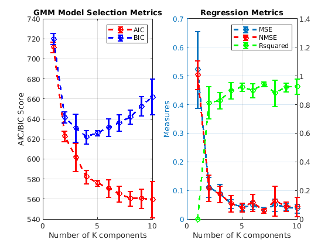

```matlab
plot_gmr_cross_validation(metrics, k_range)
```

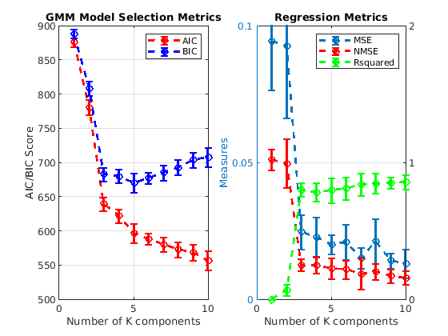

```matlab
plot_gmr_cross_validation(metrics, k_range)
```

**Note:** Graphs were generated for a range of k values incremented 1 by 1. For time constraints, in case the code is not optimized, the assignment provides a range of k values incremented 2 by 2. This should not change much the general look of the output graphs. You can also change it line 85 of the script `tp5_gmmapps_part3.m`.